# Lab_7

Yuan Ping

2025-03-24

1.1 load the same household data used in the Lab7_Script.R file, create the object `HTS`

```r
library(data.table)
library(foreign)
HTS <- data.table(read.spss("datasets/HTS.household.10regions.sav",to.data.frame = T))
```

```
## re-encoding from CP1252
```

```r
# 2. Recreate the same steps used in the lab to run a T-test, but instead, consider the following:
# 2.1 Run a T-Test to show if the household income means is statistically different between households living in single family residences or not (use the whole sample). Produce two pdfs, one with an histogram pdf plot, and another with the simulated hypothesis testing plot showing where the T-statistic falls. Provide a short interpretation of your results
library(ggplot2)
names(HTS)
```

```
##  [1] "rhhnum"       "region"       "geoid10"      "anyvmt"       "lnvmt"
##  [6] "autotrips"    "anywalk"      "walktrips"    "anybike"      "biketrips"
## [11] "anytransit"   "transittrips" "veh"          "hhsize"       "hhworker"
## [16] "htype"        "sf"           "hhincome"     "lnhhincome"   "income_cat"
## [21] "actden"       "jobpop"       "entropy"      "intden"       "pct4way"
## [26] "stopden"      "emp10a"       "emp20a"       "emp30a"       "emp30t"
## [31] "intptlat10"   "intptlon10"
```

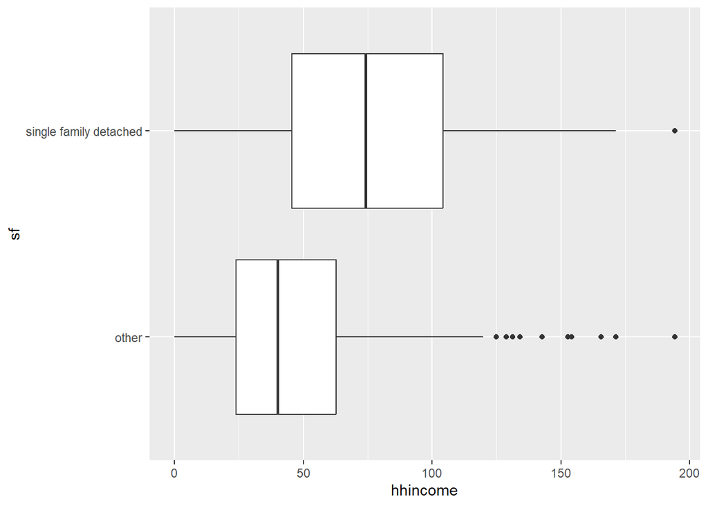

```r
HTS_clean <- HTS[!is.na(sf) & !is.na(hhincome), ]
ggplot(data=HTS_clean,aes(x=hhincome, y=sf))+
  geom_boxplot()
```

```r
t_result<-t.test(hhincome ~ sf, data = HTS_clean)
print(t_result)
```

```
##
##  Welch Two Sample t-test
##
## data:  hhincome by sf
## t = -36.234, df = 4353.4, p-value < 2.2e-16
## alternative hypothesis: true difference in means between group other and group single family detached is not equal to 0
## 95 percent confidence interval:
##  -30.19913 -27.09895
## sample estimates:
##                  mean in group other mean in group single family detached
##                             46.73311                             75.38215
```

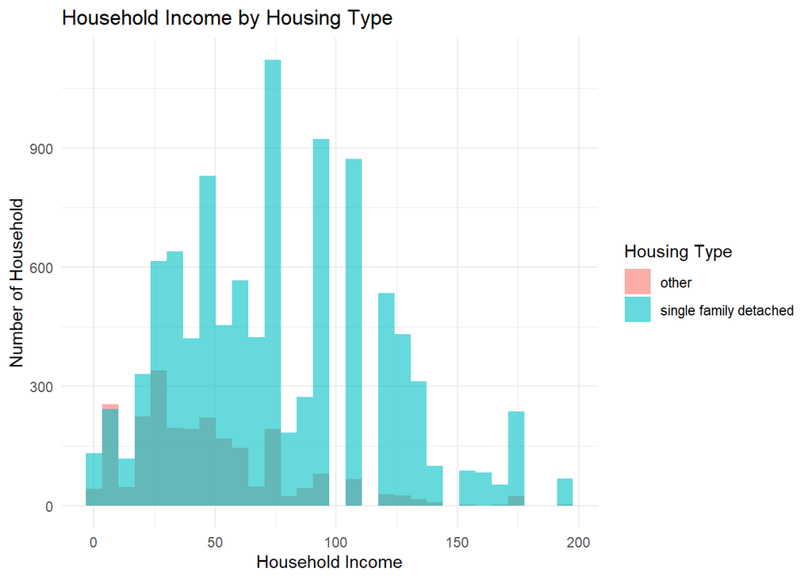

```r
library(ggplot2)
ggplot(HTS_clean, aes(x = hhincome, fill = sf)) +
  geom_histogram(alpha = 0.6, bins = 30, position = "identity") +
  labs(title = "Household Income by Housing Type",
       x = "Household Income",
       y = "Number of Household",
       fill = "Housing Type") +
  theme_minimal()
```

```r
ggsave("income_histogram.pdf", plot = last_plot(), width = 8, height = 5)


pdf("t_distribution_plot.pdf", width = 8, height = 5)
t_stat <- as.numeric(t_result$statistic)
df <- as.numeric(t_result$parameter)

curve(dt(x, df = df), from = -50, to = 50,
      main = "T-distribution with Observed T-statistic",
      xlab = "t value", ylab = "Density",
      col = "darkgreen", lwd = 2)

abline(h = 0, col = "blue")
points(x = t_stat, y = 0, col = "red", pch = 19, cex = 1.5)
legend("topright",
       legend = paste("t =", round(t_stat, 2)),
       col = "red", pch = 19)

dev.off()
```

```r
# The test shows a t-statistic of -36.234 with 4353.4 degrees of freedom and a p-value less than 2.2e-16, indicating a highly statistically significant difference. The mean household income for those living in other housing types was $46.73, while for those in single family residences it was $75.38. The 95% confidence interval for the difference in means is from -30.20 to -27.10, which does not include zero, further confirming the result.
#Therefore, we reject the null hypothesis and conclude that households in single family residences have significantly higher average incomes compared to those in other housing types.
```

# 2.2 Filter the sample to select only the region of San Antonio. Prepare an T-Test to show if the household vehicle miles traveled (in natural logs - lnvmt) is statistically different between households living in neighborhoods with a job-population index (variable `jobpop`) over and under the city median (of the `jobpop` variable of course)

```r
HTS_SA<-HTS[region=="San Antonio, TX",]
median_jobpop <- median(HTS_SA$jobpop, na.rm = TRUE)
HTS_SA$jobpop_group <- ifelse(HTS_SA$jobpop > median_jobpop, "High Jobpop", "Low Jobpop")
HTS_SA$jobpop_group <- factor(HTS_SA$jobpop_group)
unique(HTS_SA$jobpop_group)
```

```
## [1] High Jobpop Low Jobpop
## Levels: High Jobpop Low Jobpop
```

```r
t_result_SA <- t.test(lnvmt ~ jobpop_group, data = HTS_SA)
print(t_result_SA)
```

```
##
##  Welch Two Sample t-test
##
## data:  lnvmt by jobpop_group
## t = -2.2052, df = 1512.2, p-value = 0.02759
## alternative hypothesis: true difference in means between group High Jobpop and group Low Jobpop is not equal to 0
## 95 percent confidence interval:
##  -0.21709014 -0.01269755
## sample estimates:
## mean in group High Jobpop  mean in group Low Jobpop
##                  2.989259                  3.104152
```

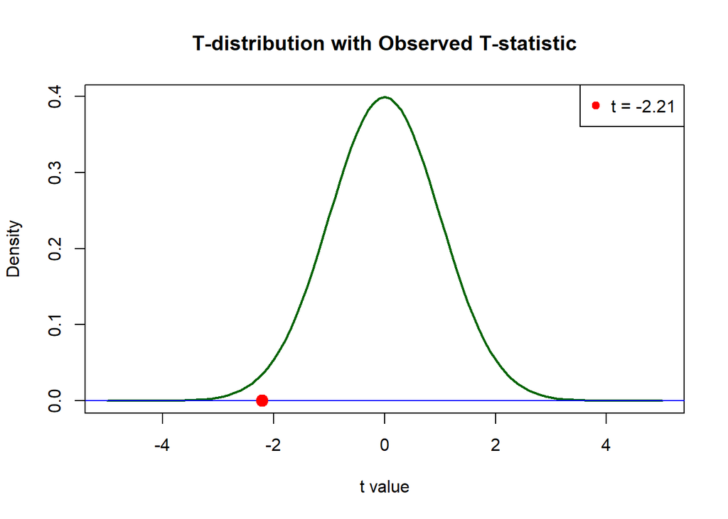

```r
t_stat_SA <- as.numeric(t_result_SA$statistic)
df_SA <- as.numeric(t_result_SA$parameter)

curve(dt(x, df = df), from = -5, to = 5,
      main = "T-distribution with Observed T-statistic",
      xlab = "t value", ylab = "Density",
      col = "darkgreen", lwd = 2)

abline(h = 0, col = "blue")
points(x = t_stat_SA, y = 0, col = "red", pch = 19, cex = 1.5)
legend("topright",
       legend = paste("t =", round(t_stat_SA, 2)),
       col = "red", pch = 19)
```

```r
#The results show a statistically significant difference between the two groups (t = -2.21, df = 1512.2, p = 0.028). Households in high job-population areas had a lower average lnvmt (mean = 2.99) compared to those in low job-population areas (mean = 3.10). The 95% confidence interval for the difference in means is from -0.217 to -0.013, which does not include zero, indicating that the observed difference is unlikely due to chance.
#These findings suggest that households living in neighborhoods with a high job-population index tend to travel fewer vehicle miles on average.
```

2.2 using the same data set (San Antonio sample), run an ANOVA test to see if there are significant differences between income categories and vehicle miles traveled by household. Follow the same steps used in the ANOVA exercise done in class. Produce three pdfs: one checking the normality assumption of the dependent variable, a second one checking the presence of outliers, and a third one showing the Tukey (post hoc) T-tests plot.

```r
pdf("hist_lnvmt.pdf", width = 8, height = 5)
hist(HTS_SA$lnvmt,col = "lightblue", border = "white")
dev.off()
```

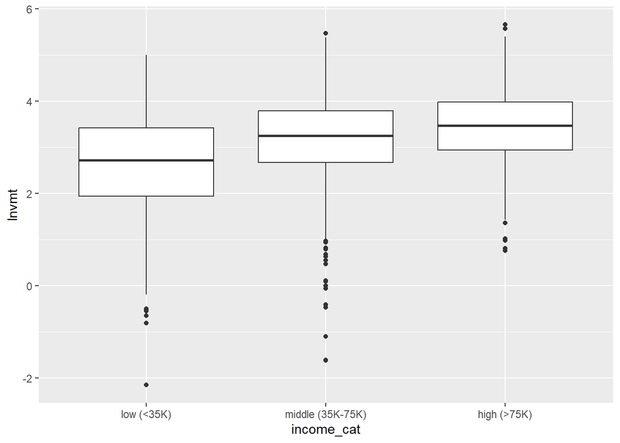

```r
#Find the outliers
ggplot(data=HTS_SA, aes(x=income_cat, y= lnvmt))+
  geom_boxplot()
```